# 4. Fisheries production models

Beth Babcock

2025-09-02

```r
library(ggplot2)
theme_set(theme_bw())
```

### Fitting a model with Bayesian methods

This is the same data we looked at for a normal likelihood.

```r
data<-data.frame(i=1:30,x=c(7.72, 4.79, 5.78, 4.89, 2.25, 4.17, 4.21, 4.88, 7.2, 6.53, 4.67, 4.49, 6.39, 6.11, 3.62, 3.59, 5.73, 6.54, 4.78, 6.76, 5.8,
3.78, 5.68, 2.74, 7.87, 8.96, 4.27, 2.91, 6.14, 4.73))
```

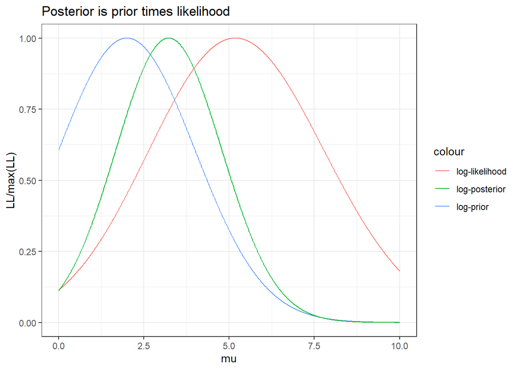

```r
priormean<-2
priorsd<-2
posterior<-data.frame(mu=seq(0,10,0.01))
for(i in 1:nrow(posterior)) {
 posterior$LL[i]<-sum(dnorm(data$x,mean=posterior$mu[i],sd=2))
}
posterior$logprior<-dnorm(posterior$mu,mean=priormean,sd=priorsd)
posterior$logposterior<-posterior$LL*posterior$logprior
ggplot(posterior,aes(x=mu))+
  geom_line(aes(y=LL/max(LL),color="log-likelihood"))+
  geom_line(aes(y=logprior/max(logprior),color="log-prior"))+
  geom_line(aes(y=logposterior/max(logposterior),color="log-posterior"))+
  ggtitle("Posterior is prior times likelihood")
```

Same with a less informative prior

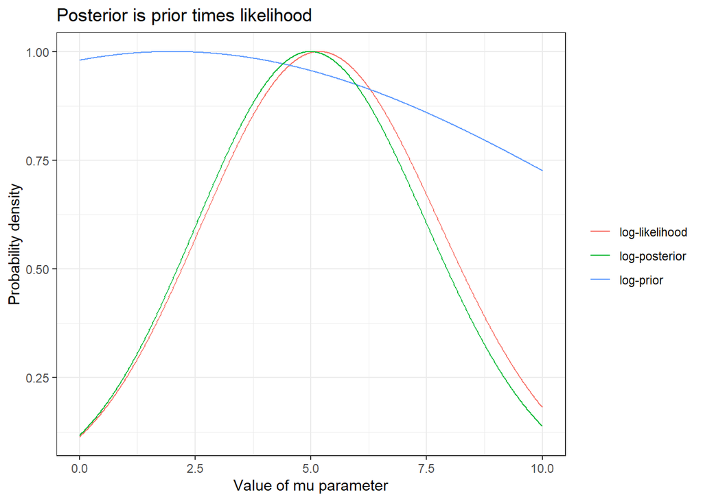

```r
priormean<-2
priorsd<-10
posterior<-data.frame(mu=seq(0,10,0.01))
for(i in 1:nrow(posterior)) {
 posterior$LL[i]<-sum(dnorm(data$x,mean=posterior$mu[i],sd=2))
}
posterior$logprior<-dnorm(posterior$mu,mean=priormean,sd=priorsd)
posterior$logposterior<-posterior$LL*posterior$logprior
ggplot(posterior,aes(x=mu))+
  geom_line(aes(y=LL/max(LL),color="log-likelihood"))+
  geom_line(aes(y=logprior/max(logprior),color="log-prior"))+
  geom_line(aes(y=logposterior/max(logposterior),color="log-posterior"))+
  ggtitle("Posterior is prior times likelihood")+
  labs(y="Probability density",x="Value of mu parameter",color="")
```

Posterior is more similar to the likelihood

Now make a function to minimize to get the mode of the posterior distribution

```r
getNegLogPosterior<-function(theta,data) {
    LL<-dnorm(x=data$x, #data is an input, with a variable called x
              mean=theta["mu"], #mean is the parameter we want to calculate
              sd=2,
              log=TRUE) #fix standard deviation for this example
    logprior<-dnorm(theta["mu"],data$priormean,data$priorsd,log=TRUE)
    -sum(LL)-logprior  #return negative total log likelihood plus priors
}
getNegLogPosterior(c(mu=5.2),list(x=data$x,priormean=2,priorsd=2))
```

```
##       mu
## 60.44321
```

Use minimizer function optim to find the value of mu that has the lowest -logposterior

```r
modFit<-optim(par=c(mu=3),
              fn=getNegLogPosterior,
              data=list(x=data$x,priormean=2,priorsd=2),
              method="L-BFGS-B")
modFit$par
```

```
##       mu
## 5.160645
```

### Bayesian production models in R.

Possible priors

```r
dlogunif<-function(x,minval,maxval,logTrans=TRUE) {
  if(minval==0) minval<-0.0000001
  prob<-1/(x*(log(maxval)-log(minval)))
  if(logTrans) return<-log(prob) else
    return=prob
  return
}
dlogunif(1,0,1000,logTrans=FALSE)
```

```
## [1] 0.04342945
```

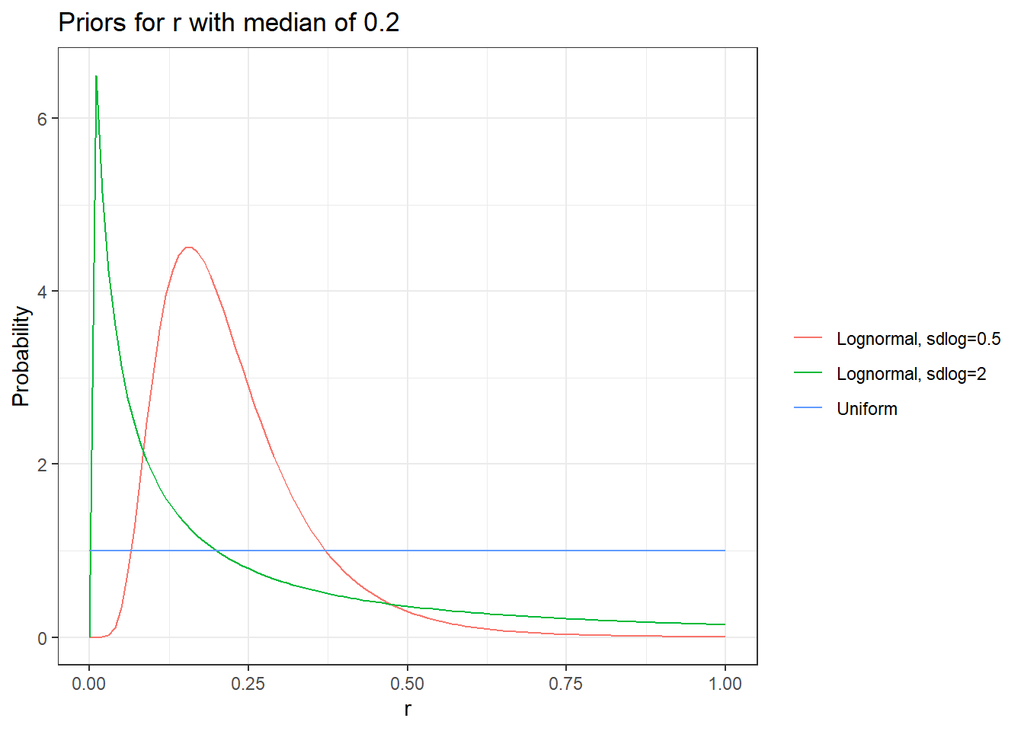

```r
ggplot(data.frame(r=c(0,1)),aes(x=r))+
  geom_function(aes(color="Lognormal, sdlog=0.5"),
                fun=dlnorm,
                args=list(meanlog = log(0.2), sdlog = 0.5))+
  geom_function(aes(color="Lognormal, sdlog=2"),
                fun=dlnorm,
                args=list(meanlog = log(0.2), sdlog = 2))+
  geom_function(aes(color="Uniform"),
                fun=dunif,
                args=list(min=0,max=1))+
  ggtitle("Priors for r with median of 0.2")+
  labs(x="r",y="Probability",color="")
```

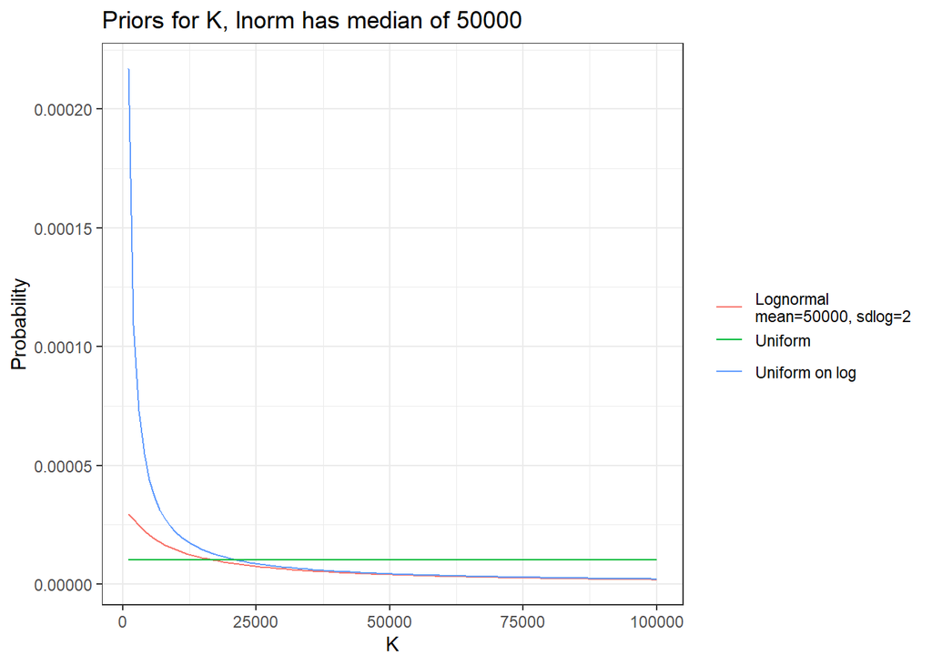

```r
ggplot(data.frame(K=c(1000,100000)),aes(x=K))+
  geom_function(aes(color="Lognormal\nmean=50000, sdlog=2"),
                fun=dlnorm,
                args=list(meanlog = log(50000), sdlog = 2))+
  geom_function(aes(color="Uniform on log"),
                fun=dlogunif,
                args=list(minval=1000,maxval=100000,logTrans=FALSE))+
  geom_function(aes(color="Uniform"),
                fun=dunif,
                args=list(min=1000,max=100000))+
  ggtitle("Priors for K, lnorm has median of 50000")+
  labs(x="K",y="Probability",color="")
```

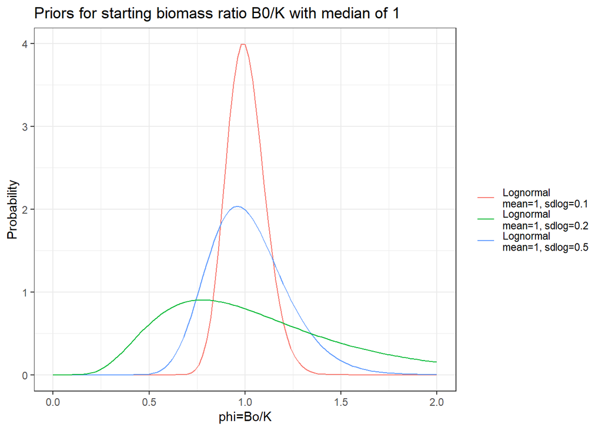

```r
ggplot(data.frame(phi=c(0,2)),aes(x=phi))+
  geom_function(aes(color="Lognormal\nmean=1, sdlog=0.1"),
                fun=dlnorm,
                args=list(meanlog = log(1), sdlog = 0.1))+
  geom_function(aes(color="Lognormal\nmean=1, sdlog=0.5"),
                fun=dlnorm,
                args=list(meanlog = log(1), sdlog = 0.2))+
  geom_function(aes(color="Lognormal\nmean=1, sdlog=0.2"),
                fun=dlnorm,
                args=list(meanlog = log(1), sdlog = 0.5))+
  ggtitle("Priors for starting biomass ratio B0/K with median of 1")+
  labs(x="phi=Bo/K",y="Probability",color="")
```

### Using JABBA

First, install JABBA and JAGS

```r
# Installation
# install.packages(devtools)
# devtools:: install_github("jabbamodel/JABBA")
```

Original South Atlantic Swordfish example Winker et al. (2018). JABBA: Just Another Biomass Assessment

```r
library(JABBA)
swos <- iccat$swos

assessment <- "SWOSiccat"
scenario <- "Schaefer"

File <- getwd() #"C:/Users/Elizabeth A Babcock/Box/RSM 612/RSM 612 lectures" # LINK to your folder of choice here
assessment<-"SWO"
output.dir = file.path(File,assessment)
dir.create(output.dir,showWarnings = FALSE)
```

### Compile JABBA JAGS model and input object

```r
jbswos <- build_jabba(catch=swos$catch,  #vector of catches
                      cpue=swos$cpue,  #data frame of CPUE by fleet
                      se=swos$se,  #input standard deviations.
                      assessment=assessment, #name of assessment
                      scenario = scenario, #scenario name
                      model.type = "Schaefer",  #Schaefer is the logistic model
                      r.prior=c(0.42,0.37), #mean and log-sd for lognormal
                      K.prior = c(250000,1), #mean and log-sd for lognormal
                      psi.prior = c(1,0.25), #mean and log-sd for lognormal
                      sigma.est = TRUE,  # observation error by fleet
                      igamma=c(4,0.01), # default process error
                      P_bound = c(0.02,1.1),
                      verbose=FALSE, #Bounds of B/K
                      sigmaobs_bound = 0.1, #upper limit of observation error
                      sigmaproc_bound = 0.2) #upper limit of process error)
```

Plot indices

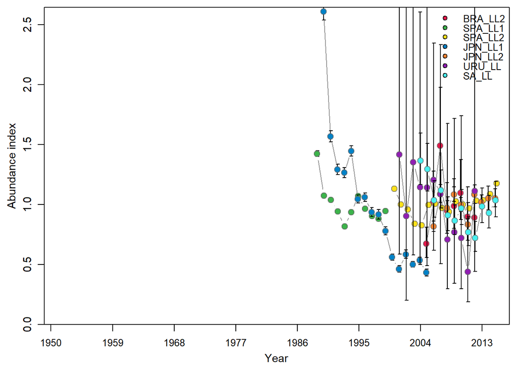

```r
jbplot_indices(jbswos)
```

fit JABBA

This is running a model in JAGS so it takes some time

```r
fit.swos <- fit_jabba(jbswos,  #the build_jabba object
                      save.jabba=TRUE,  #TO save the directory
                      output.dir=output.dir,
                      ni = 50000,  #ni,nt,nb and nc are MCMC settings
                      nt = 10,
                      nb = 5000,
                      nc = 2)
```

```
## module glm loaded
```

```
##
## ><> Produce results output of Schaefer model for SWO Schaefer <><
```

[output not shown]

Plots to see if the MCMC converged

```
##
## ><> jbplot_mcmc() - mcmc chains  <><
```

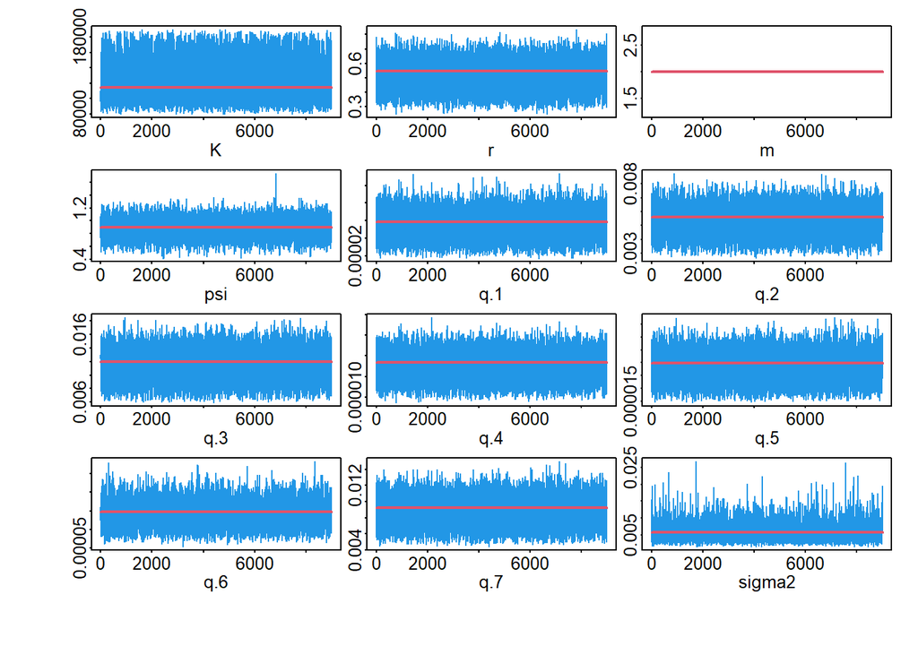

```r
jbplot_mcmc(fit.swos)
```

```
##
## ><> jbplot_ppist() - prior and posterior distributions  <><
```

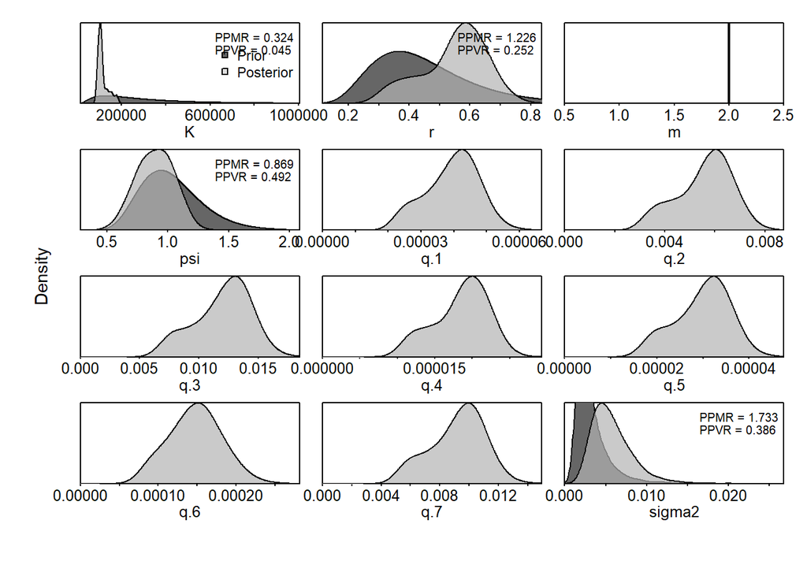

```r
jbplot_ppdist(fit.swos)  #Posterior and prior distributions
```

```
##
## ><> jrplot_PPC() - Posterior Predictive Checks <><
```

```
##
##  Posterior Predictive Checks with Bayesian p values
```

```
##      Index  Bayesian.p nobs
## 1  BRA_LL2 0.075777778    8
## 2  SPA_LL1 0.010888889   11
## 3  SPA_LL2 0.524333333   16
## 4  JPN_LL1 0.004444444   16
## 5  JPN_LL2 0.349444444   10
## 6   URU_LL 0.811333333   12
## 7    SA_LL 0.006888889   12
## 8 Combined 0.254730159   85
```

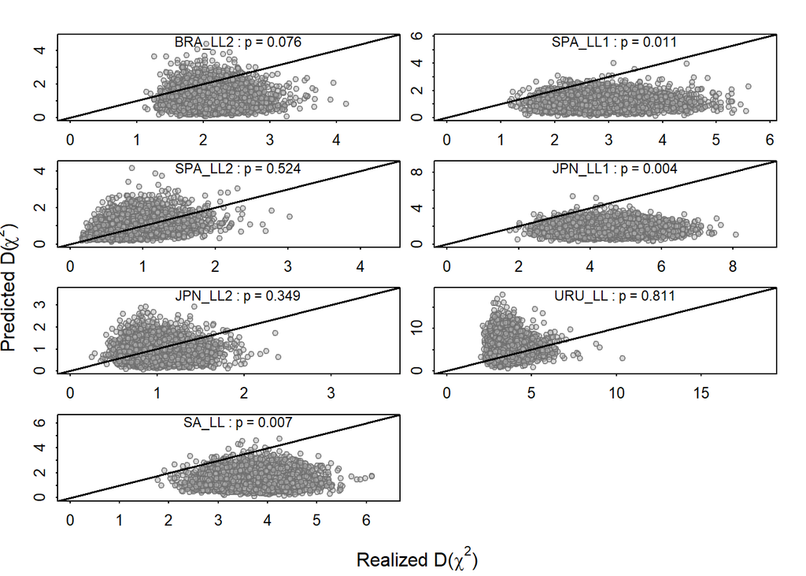

```r
jbplot_PPC(fit.swos)  #Posterior predictive checks
```

Make some plots to see if the fit is good

```
##
## ><> jbplot_catch()  <><
```

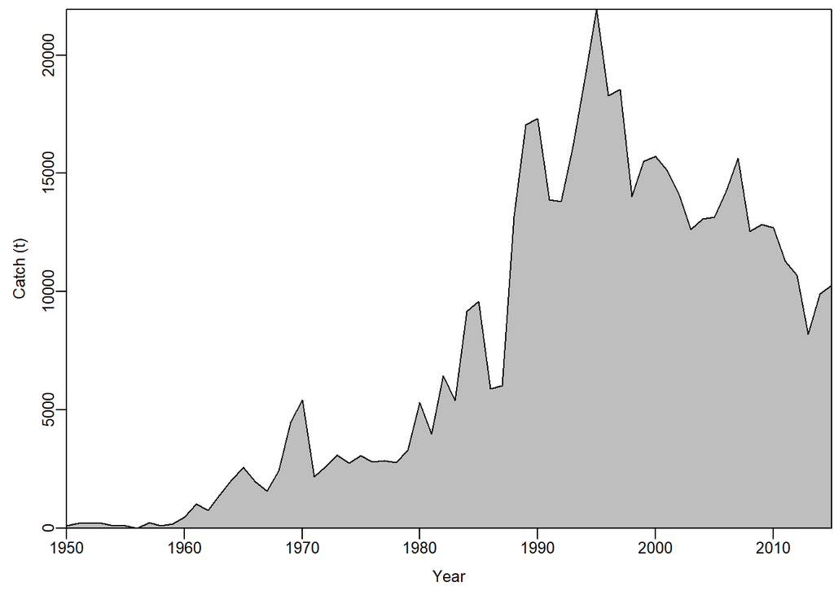

```r
jbplot_catch(fit.swos)  #catches
```

```r
jbplot_cpuefits(fit.swos)  #Fits to CPUE indices
```

```
##
## ><> jbplot_cpue() - fits to CPUE <><
```

[figure not shown]

```
##
## ><> jbplot_cpue() - fits to CPUE <><
```

```r
jbplot_logfits(fit.swos)   #Fits to CPUE indices in log scale
```

[figure not shown]

```
##
## ><> jbplot_cpue() - fits to CPUE <><
```

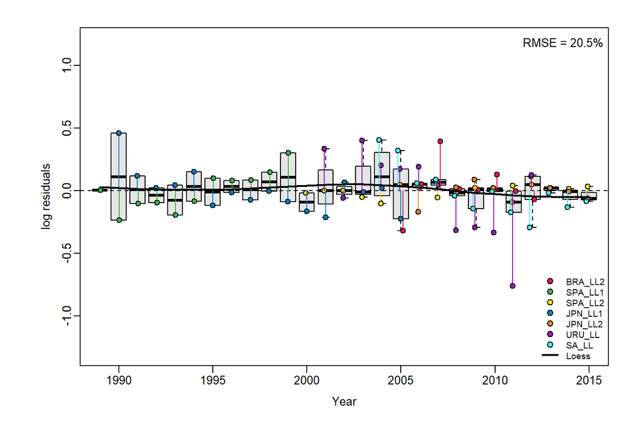

```r
jbplot_residuals(fit.swos)  # Residuals
```

```
##
## ><> jbplot_runstest()   <><
```

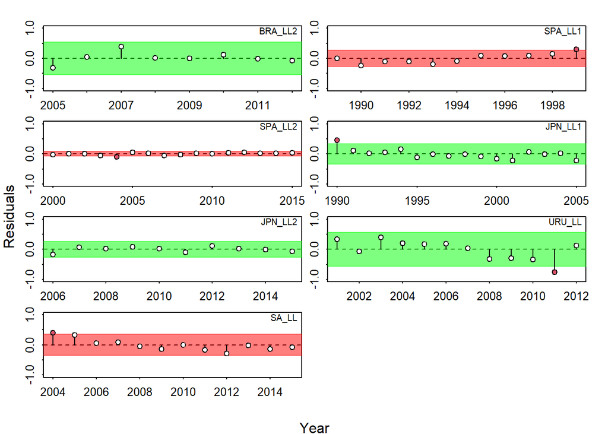

```r
jbplot_runstest(fit.swos)  # A test of whether there are patterns in residuals
```

Plots to see the status of the population

```r
jbplot_ensemble(fit.swos,subplots=1:2)
jbplot_kobe(fit.swos)
```

[output not shown]

```
##
## ><> jbplot_kobe() - Stock Status Plot  <><
```

```r
jbplot_spphase(fit.swos)
```

[output not shown]

```
##
## ><> jbplot_spphase() - JABBA Surplus Production Phase Plot  <><
```

### Projections

ICCAT Style projections, based on a TAC: total allowable catch

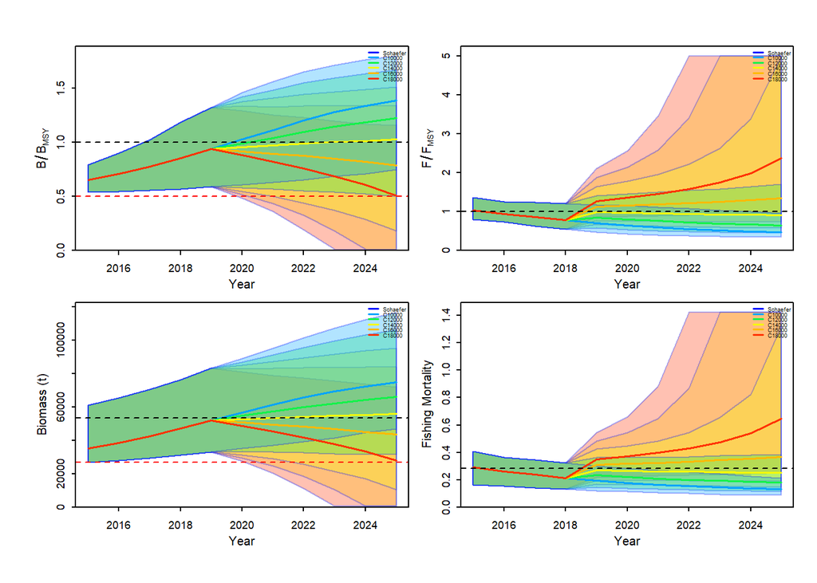

```r
Ccur = 10056
TACs = seq(10000,18000,2000)
fw.swos= fw_jabba(fit.swos,nyears=10,imp.yr=4,
                  initial = Ccur,
                  imp.values = TACs,
                  quant="Catch",type="abs",
                  nsq=3,stochastic = T,AR1=F)
jbpar(mfrow=c(2,2),plot.cex = 0.7)
jbplot_ensemble(fw.swos,legendcex = 0.4,xlim=c(2015,2025),subplots = c(1:4),add=T)
```

### Hindcast cross-validation and retrospective analysis

```
##
## ><> jbplot_retro() - retrospective analysis <><
```

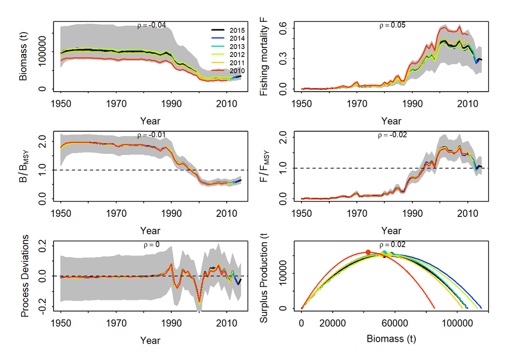

```
##                  B            F         Bmsy        Fmsy         procB
## 2015    0.06331056 -0.057712989  0.026847308 -0.03037881  0.0023464341
## 2014   -0.03266532  0.002394098  0.003102544 -0.05808556  0.0070157129
## 2013    0.06422521 -0.069060108 -0.002844063 -0.01551452  0.0004132626
## 2012   -0.08315865  0.139381127 -0.052558598  0.07217953 -0.0055057080
## 2011   -0.23182785  0.251658125 -0.038835682 -0.05768304  0.0051419451
## rho.mu -0.04402321  0.053332051 -0.012857698 -0.01789648  0.0018823293
##                MSY
## 2015   0.001337142
## 2014   0.026769865
## 2013   0.010537331
## 2012   0.018672630
## 2011   0.060790984
## rho.mu 0.023621591
```

```r
hc1 <- hindcast_jabba(jbswos,fit.swos,peels=1:5)
 # Show Retrospective Pattern
jbplot_retro(hc1)
```

```
##
##  ><> Only including indices that have years overlapping hind-cast horizan
##
##  ><> Including indices: BRA_LL2 SPA_LL2 JPN_LL2 URU_LL SA_LL
##
##  Computing MASE with only 2 of 5  prediction residuals for Index BRA_LL2
##
##  Warning:  Unequal spacing of naive predictions residuals may influence the interpretation of MASE
##
##
## No observations in evaluation years to compute prediction residuals for Index SPA_LL1
##
##  Computing MASE with all 5 of 5  prediction residuals for Index SPA_LL2
##
## No observations in evaluation years to compute prediction residuals for Index JPN_LL1
##
##  Computing MASE with all 5 of 5  prediction residuals for Index JPN_LL2
##
##  Computing MASE with only 2 of 5  prediction residuals for Index URU_LL
##
##  Warning:  Unequal spacing of naive predictions residuals may influence the interpretation of MASE
##
##
##  Computing MASE with all 5 of 5  prediction residuals for Index SA_LL
```

```
##     Index      MASE  MASE.adj     MAE.PR   MAE.base n.eval
## 1 BRA_LL2 0.5087284 0.3541842 0.05305869 0.10429670      2
## 2 SPA_LL1        NA        NA         NA         NA      0
## 3 SPA_LL2 1.1222403 0.5137691 0.05137691 0.04578067      5
## 4 JPN_LL1        NA        NA         NA         NA      0
## 5 JPN_LL2 1.0979367 0.7926831 0.11811819 0.10758197      5
## 6  URU_LL 0.7730865 0.7730865 0.55271995 0.71495223      2
## 7   SA_LL 1.3835771 1.2502502 0.21123200 0.15267092      5
## 8   joint 0.9831245 0.9831245 0.16395752 0.16677188     19
```

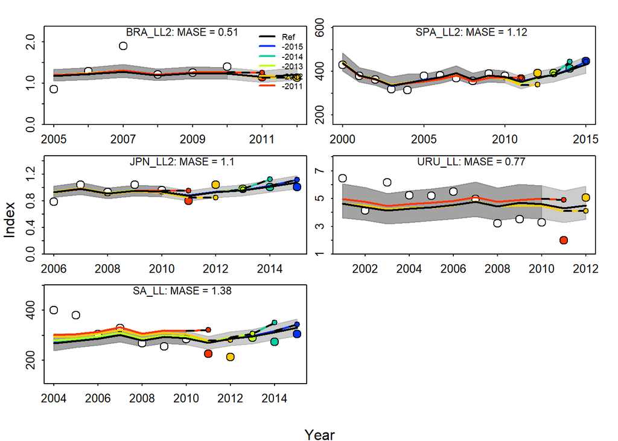

```r
jbplot_hcxval(hc1)
```

### Pella-Tomlinson model

```r
scenario<-"Pella"
jbswos <- build_jabba(catch=swos$catch,  #vector of catches
                      cpue=swos$cpue,  #data frame of CPUE by fleet
                      se=swos$se,  #input standard deviations.
                      assessment=assessment, #name of assessment
                      scenario = scenario, #scenario name
                      model.type = "Pella",  #Pella is an assymetric yield curve,
                      BmsyK = 0.4, #Location of Bmsy/K
                      r.prior=c(0.42,0.37), #mean and log-sd for lognormal
                      K.prior = c(250000,1), #mean and log-sd for lognormal
                      psi.prior = c(1,0.25), #mean and log-sd for lognormal
                      sigma.est = TRUE,  # observation error by fleet
                      igamma=c(4,0.01), # default process error
                      P_bound = c(0.02,1.1), #Bounds of B/K
                      sigmaobs_bound = 0.1, #upper limit of observation error
                      sigmaproc_bound = 0.2) #upper limit of process error)
```

```
##
## ><> Prepare JABBA input data <><
```

```
##
## ><> Assume Catch with error CV = 0.1 <><
```

```
##
## ><> Model type:Pella <><
```

```
##
## ><> Shape m =1.188
```

```
##
## ><> K prior mean =250000and CV =1(log.sd = 0.832554611157698)
```

```
##
## ><> r prior mean =0.42and CV =0.383031945716667(log.sd = 0.37)
```

```
##
## ><> Psi (B1/K) prior mean =1and CV =0.25withlnormdestribution
```

```
##
##
##
## ><> ALWAYS ENSURE to adjust default settings to your specific stock <><
```

```r
fit.swos2 <- fit_jabba(jbswos,  #the build_jabba object
                      save.jabba=TRUE,  #TO save the directory
                      output.dir=output.dir,
                      ni = 50000,  #ni,nt,nb and nc are MCMC settings
                      nt = 10,
                      nb = 5000,
                      nc = 2)
```

```
##
## ><> Produce results output of Pella model for SWO Pella <><
```

```
##
##
## ><> Scenario Pella_Pella completed in 3 min and 30 sec <><
```

```r
save.image()
```

Plot yield curve with status

```
##
## ><> jbplot_spdyn() - SPt+1 = Bt+1-Bt+Ct vs B  <><
```

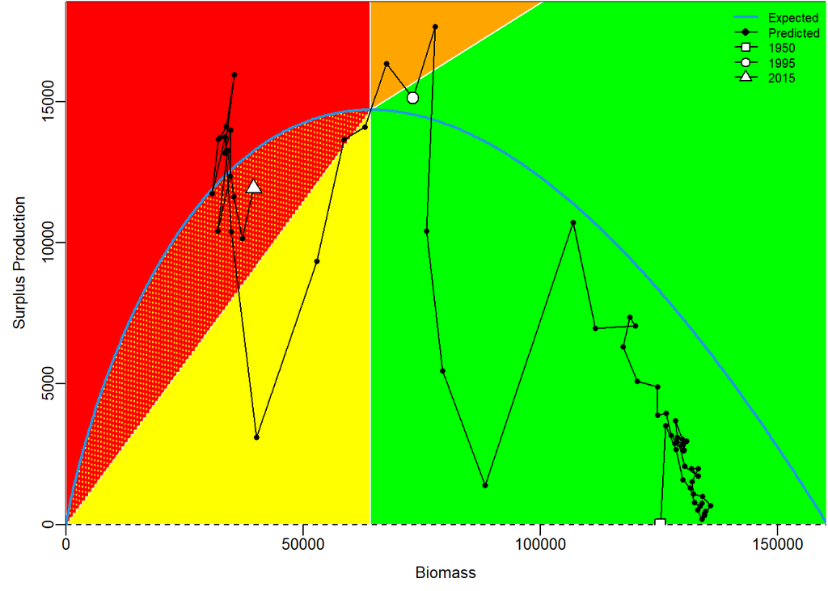

```r
jbplot_spdyn(fit.swos2)
```

Compare runs

```r
jbplot_ensemble(list(fit.swos,fit.swos2),subplots=1:2)
jbplot_kobe(fit.swos2)
```

[output not shown]

```
##
## ><> jbplot_kobe() - Stock Status Plot  <><
```

```r
jbplot_spphase(fit.swos2)
```

[output not shown]

```
##
## ><> jbplot_spphase() - JABBA Surplus Production Phase Plot  <><
```